# Longitudinal Project Update: EDA

Brenton Graham

2022-11-18

## Background

Pulmonary exacerbations (PEx) are a leading cause of morbidity in cystic fibrosis (CF). Treatment response is often suboptimal despite seemingly appropriate antimicrobial therapy. In this study, we seek to determine changes in airway microbiome and clinical response with onset and treatment of a PEx in children and adolescents with CF. Participants hospitalized for PEx were evaluated at admission, hospital discharge and a follow-up clinic visit. Sputum and blood samples were collected along with lung function and PEx score. Quantitative CF cultures were performed. Sputum and plasma were analyzed for inflammatory and protein markers.

## Data

### Subjects & Repeated Measures

Data from 21 unique subjects and 23 pulmonary exacerbations are present in this data set (i.e., two subjects had exacerbations on two separate occasions). For each exacerbation there are three repeated measures (T1 = Admission, T2 = Hospital Discharge, T3 = Follow-Up Visit). Time points are approximately separated by 10-14 days.

Table 1. Demographics of study population.

|  | Overall (N=23) |
| --- | --- |
| gender |  |
| Male | 11 (47.8%) |
| Female | 12 (52.2%) |
| age |  |
| Mean (SD) | 16.0 (2.80) |
| Median [Min, Max] | 15.9 [11.9, 22.0] |
| bmi |  |
| Mean (SD) | 20.1 (2.75) |
| Median [Min, Max] | 19.5 [16.4, 28.7] |
| genotype |  |
| 0 F508del | 2 (8.7%) |
| 1 F508del | 5 (21.7%) |
| 2 F508del | 16 (69.6%) |
| admit.cf_pathogens |  |
| 0 | 2 (8.7%) |
| 1 | 12 (52.2%) |
| 2 | 6 (26.1%) |
| 3 | 2 (8.7%) |
| Missing | 1 (4.3%) |
| admit.coinfect |  |
| 0 | 10 (43.5%) |
| 1 | 8 (34.8%) |
| Missing | 5 (21.7%) |

### Variable Description

#### Outcomes

We’re interested in modeling several potential response outcomes over time, including the following.

- fev1_pred: FEV1, a measure of lung function (the higher the better)
- pes_total: PEx score (the lower the better)
- crp: C-reactive protein, a measure of inflammation (the lower the better)
- elastase: An enzyme marker
- We could possibly be interested in modeling 16S taxa counts

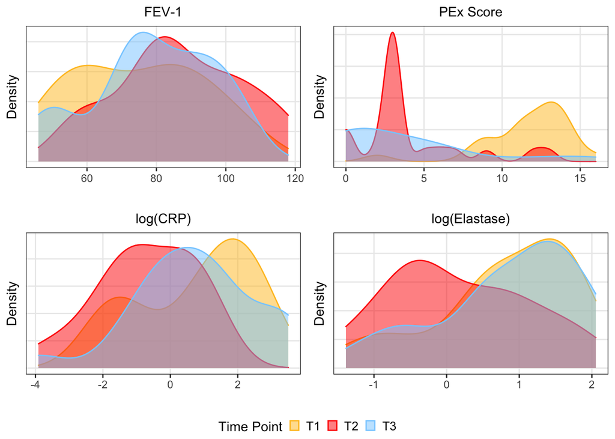

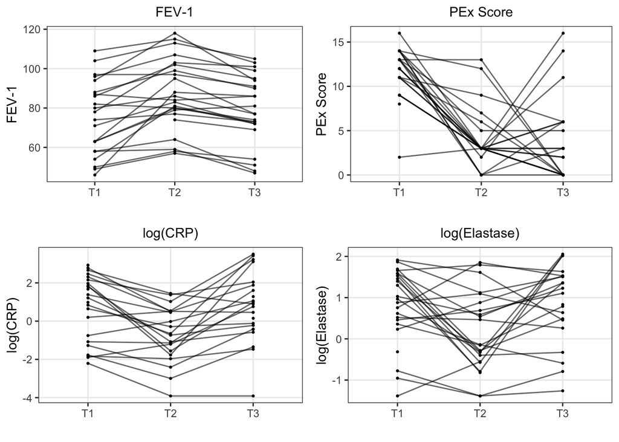

#### Explanatory Variables

In this data set we have a collection of interesting explanatory variables. These include important CF pathogen measures (from both culture and 16S rRNA sequencing) and viral measures at admission. Well known CF pathogens include Pseudomonas aeruginosa, Staphylococcus aureus, Haemophilus influenzae, Stenotrophomonas maltophilia, Achromobacter xylosoxidans and Burkholderia cepacia.

In general, we’d like to get a sense of whether or not there is anything at admission that can be used to predict the subject’s response to treatment. To simplify things, we will test two primary explanatory variables:

1. **Number of CF pathogens detected at admission.** This is the sum of binary detection results from culture. There are some studies suggesting that increased CF pathogens has negative impacts on treatment response.
2. **Bacterial/Viral co-infection at admission.** This is a binary variable that indicates whether or not **both** CF and viral pathogens were detected when the subject was admitted.

#### Additional Predictors / Precision Variables

The following variables will be included as covariates in all models.

- Gender
- Age
- BMI
- Number of hospitalizations in the past year
- Genotype: There is a specific genetic mutation of interest in CF patients. This variable indicates the number of F508del mutations.

### Missing Data in Our Outcomes

There are some missing data in our outcome variables (shown below).

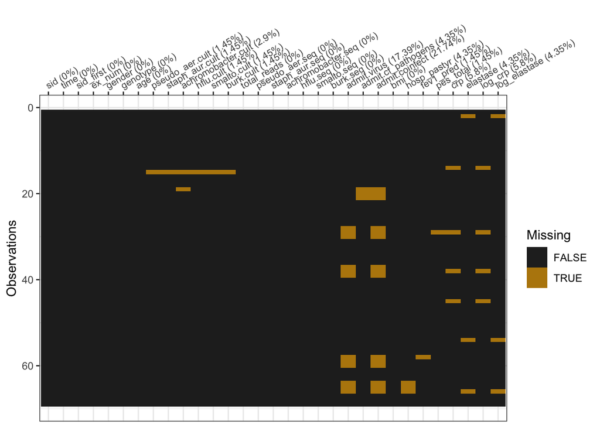

## Analysis

There aren’t necessarily any obvious grouping variables in this data set (i.e., there aren’t treatment groups for which we’d like to compare). However, we are interested in the trajectory of our outcomes and it would be biologically interesting to assess if certain factors are associated with distinct outcome trajectories. To accomplish this we can use a latent class mixture model to cluster subjects into latent classes based on outcome trajectories. Once classes are assigned, we can use post-hoc analysis methods to characterize risk factor profiles that might be driving the trajectory differences. Baseline clinical markers will be used in this latent class-separation analysis. This will allow us to determine if there are any baseline indicators of treatment response trajectory.

### Latent Class Mixed Modeling

In the first step of the analysis we will fit a latent class mixed model. Based on discussions with investigators, the elastase marker might make for the most biologically interesting latent class results. It will be most practical and appropriate to treat time as a class variable for the following reasons. First, there are only three time points, so we do not need to be concerned about the number of parameters we incorporate in the model. Second, modeling time as a class variable allows for the most flexibility. From the spaghetti plots it is obvious that the effect of time on the outcomes is not linear; quadratic relationships likely exists between time and the outcomes. Modeling time as a class variable will allow us to account for this.

Looking at the data structure, we should account for within-subject correlation. We can also consider including a random effect for the time variable since each time point relates to different outcome expectations (i.e., at time point 1 the subject is experiencing an exacerbation; at time point 2 the subject is on antibiotics and symptoms/outcomes are expected to improve). In other words, there should be some between-subject correlation at each time point. This is something that I’m not entirely confident in, however, and need to spend more time thinking about.

#### Latent Class Model Selection

This method requires users to specify the number of latent classes that should be created. As such, there is a model selection step. Below are results from models using 1-5 latent classes. Standard information criteria can be used to select the optimal number of latent classes.

```
##  Numerical problem by computing fn
##           value of function is : NaN
```

```
##    G    loglik      AIC      BIC   entropy   %class1  %class2  %class3  %class4
## m1 1 -88.70390 185.4078 189.9498 1.0000000 100.00000
## m2 2 -78.34723 172.6945 181.7784 0.9680260  13.04348 86.95652
## m3 3 -75.88404 175.7681 189.3940 0.7801455  60.86957 13.04348 26.08696
## m4 4 -70.07856 172.1571 190.3250 0.8945475  21.73913 13.04348 39.13043 26.08696
## m5 5 -63.14299 166.2860 188.9959 0.9340854  21.73913 21.73913 13.04348 13.04348
##     %class5
## m1
## m2
## m3
## m4
## m5 30.43478
```

#### Latent Class Visualization

Below we can see how these clusters look based on number of clusters and outcome trajectory.

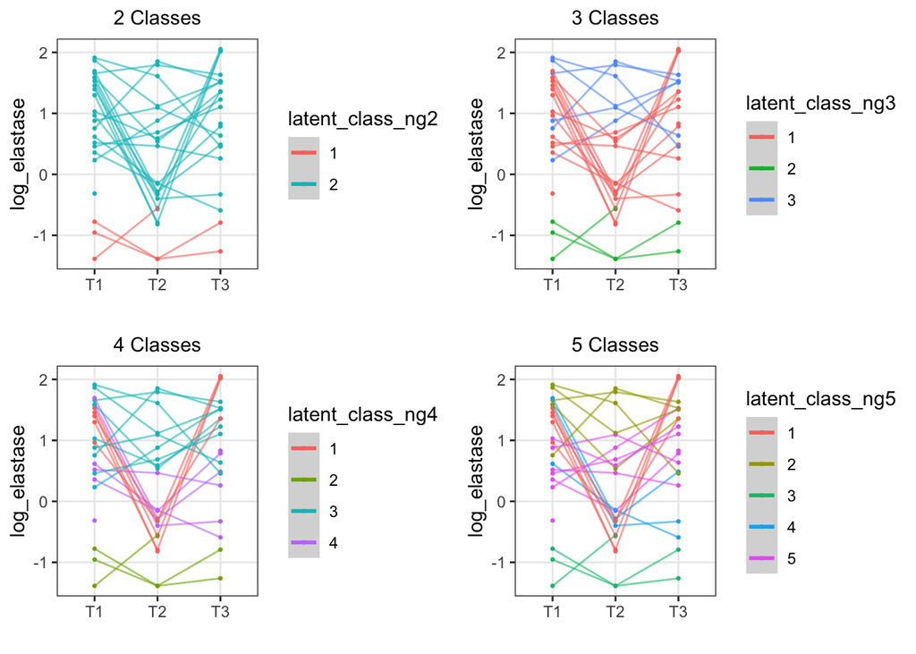

#### Mixed Model Results

Below is an example of the results that can be viewed for each model. I still need to look into which number of classes makes the most sense. We can use the table above, which displays AIC, BIC, and the number of subjects assigned to each latent class, to decide on this. I also need to figure out how to display random effects estimates.

```
## Heterogenous linear mixed model
##      fitted by maximum likelihood method
##
## hlme(fixed = log_elastase ~ time, mixture = ~time, subject = "sid",
##     ng = 5, idiag = T, data = data, verbose = F)
##
## Statistical Model:
##      Dataset: data
##      Number of subjects: 23
##      Number of observations: 66
##      Number of observations deleted: 3
##      Number of latent classes: 5
##      Number of parameters: 20
##
## Iteration process:
##      Convergence criteria satisfied
##      Number of iterations:  1
##      Convergence criteria: parameters= 3.7e-06
##                          : likelihood= 8.8e-06
##                          : second derivatives= 1.8e-09
##
## Goodness-of-fit statistics:
##      maximum log-likelihood: -63.14
##      AIC: 166.29
##      BIC: 189
##
##
## Maximum Likelihood Estimates:
##
## Fixed effects in the class-membership model:
## (the class of reference is the last class)
##
##                      coef      Se   Wald p-value
## intercept class1 -0.33229 0.62937 -0.528 0.59752
## intercept class2 -0.24483 0.67983 -0.360 0.71874
## intercept class3 -0.80142 0.71141 -1.127 0.25994
## intercept class4 -0.71100 0.71246 -0.998 0.31830
##
## Fixed effects in the longitudinal model:
##
##                      coef      Se   Wald p-value
## intercept class1  1.32525 0.17449  7.595 0.00000
## intercept class2  1.51313 0.19226  7.870 0.00000
## intercept class3 -1.03909 0.21861 -4.753 0.00000
## intercept class4  1.30462 0.21526  6.061 0.00000
## intercept class5  0.43731 0.17395  2.514 0.01194
## timeT2 class1    -1.86060 0.25447 -7.312 0.00000
## timeT2 class2    -0.14991 0.24915 -0.602 0.54739
## timeT2 class3    -0.06956 0.30917 -0.225 0.82199
## timeT2 class4    -1.61968 0.32308 -5.013 0.00000
## timeT2 class5     0.14234 0.23116  0.616 0.53806
## timeT3 class1     0.52787 0.26289  2.008 0.04464
## timeT3 class2    -0.24664 0.24142 -1.022 0.30697
## timeT3 class3     0.01201 0.34559  0.035 0.97227
## timeT3 class4    -1.44539 0.31273 -4.622 0.00000
## timeT3 class5     0.48110 0.22314  2.156 0.03108
##
##                              coef      Se
## Residual standard error:  0.37864 0.03485
```

## Looking at Relative Abundance Over Time

These are outcomes that could be jointly explored. This will be something that depends on how far we want to go. I use a log transformation here but other transformations are more widely used throughout the literature (e.g., clr transformation).

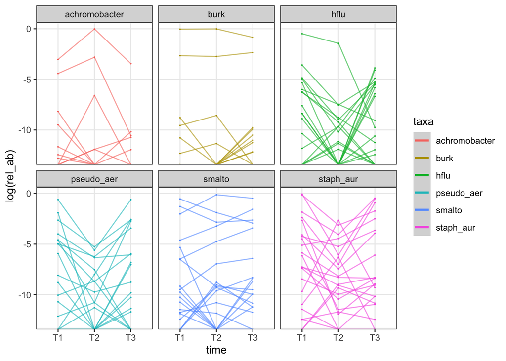